# Parameter set test

Rob Payn

12/15/2020

## Load test data

Load some realistic data for a river

```r
library(metab)
library(metabc)

load(file = "./01_input/2014-09-13/signal.RData")
```

## DO and DIC over time

Set values for test

```r
gpp <- 610
gppdo <- 1
er <- 275
erdo <- -1
k600 <- 19.5
initDO <- signalOut$getVariable("do")[1];
time <- signalOut$time
temp <- signalOut$getVariable("temp")
par <- signalOut$getVariable("par")
parTotal <- -1
airPressure <- 638
stdAirPressure <- 760

gppdic <- -1
erdic <- 1
initDIC <- signalOut$getVariable("dic")[1]
pCO2Air <- 400
alkalinity <- 2857;
```

### DO over time

Compare the GPP set to 610 (black triangles) and the GPP set to 300 (red circles), based on changing the model with the setter method.

Compare the ER set to 275 (black triangles) and the ER set to 500 (red circles), based on changing the model with the setter method.

Compare the k600 set to 19.5 (black triangles) and the k600 set to 10 (red circles), based on changing the model with the setter method.

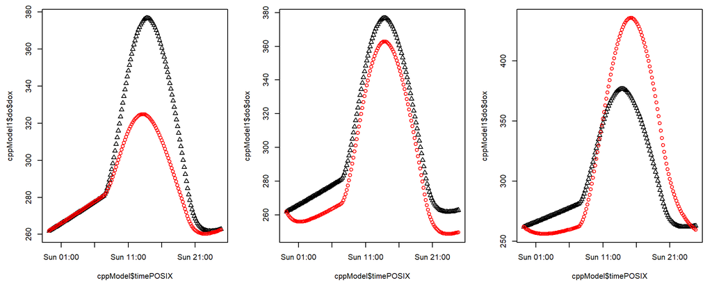

Compare the RatioDoCFix set to 1 (black triangles) and the RatioDoCFix set to 0.8 (red circles), based on changing the model with the setter method.

Compare the RatioDoCResp set to -1 (black triangles) and the RatioDoCResp set to -1.4 (red circles), based on changing the model with the setter method.

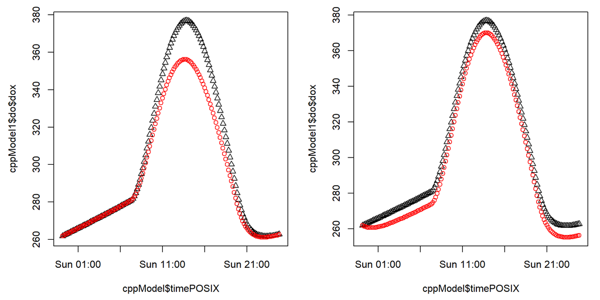

```r
par(
   mfrow = c(1, 2),
   mar = c(4.5, 4.5, 1, 1)
)

# Test RatioDoCFix
cppModel1 <- cppModel$run();

old <- cppModel$setMetabDoParam("RatioDoCFix", 0.8);

cppModel2 <- cppModel$run();

new <- cppModel$setMetabDoParam("RatioDoCFix", old);

plotComparison();

# Test RatioDoCFix
cppModel1 <- cppModel$run();

old <- cppModel$setMetabDoParam("RatioDoCResp", -1.4);

cppModel2 <- cppModel$run();

new <- cppModel$setMetabDoParam("RatioDoCResp", old);

plotComparison();
```

### DIC over time

Compare the GPP set to 610 (black triangles) and the GPP set to 300 (red circles), based on changing the model with the setter method.

Compare the ER set to 275 (black triangles) and the ER set to 500 (red circles), based on changing the model with the setter method.

Compare the k600 set to 19.5 (black triangles) and the k600 set to 10 (red circles), based on changing the model with the setter method.

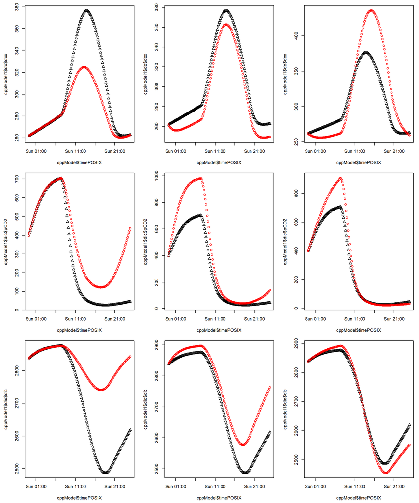

Compare the RatioDoCFix set to 1 (black triangles) and the RatioDoCFix set to 0.8 (red circles), based on changing the model with the setter method.

Compare the RatioDoCResp set to -1 (black triangles) and the RatioDoCResp set to -1.4 (red circles), based on changing the model with the setter method.

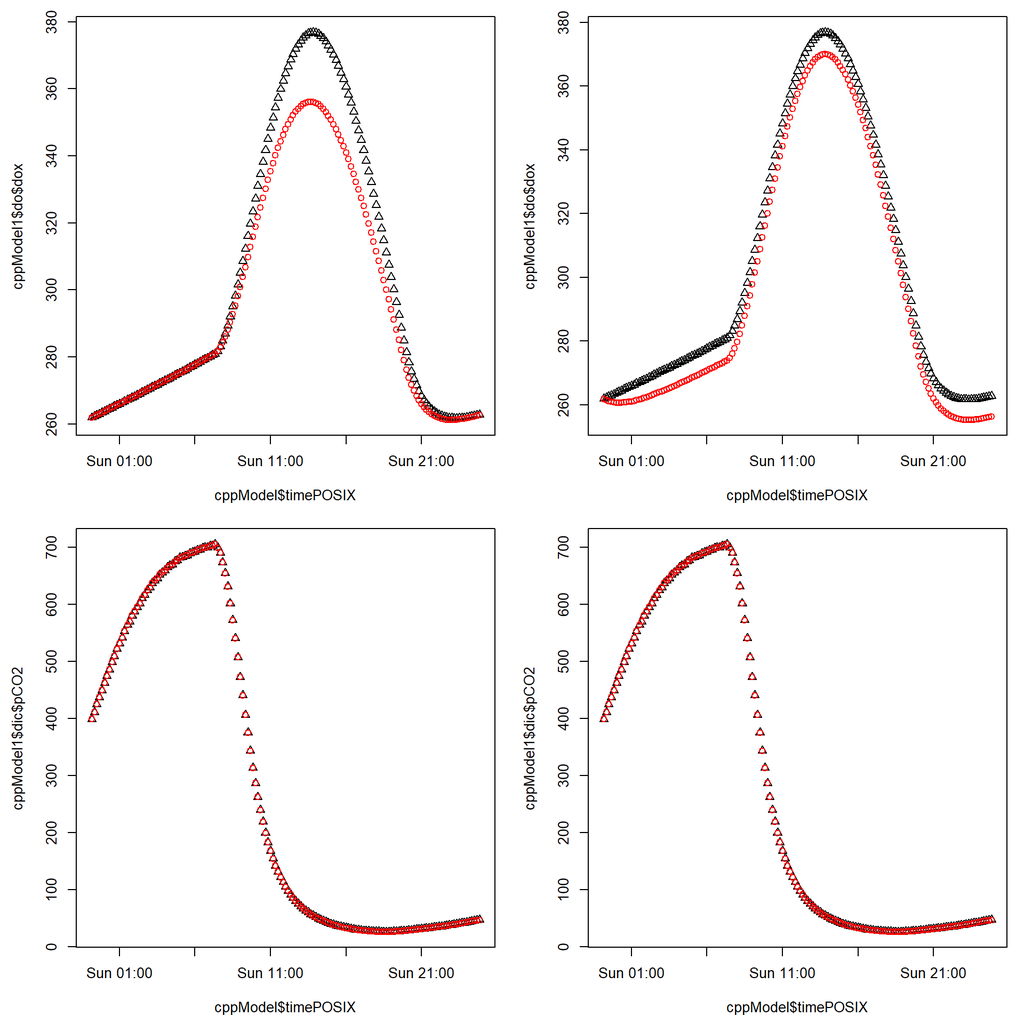

```r
cppModel <- CMetabDoDic$new(
   type = "ForwardEuler",
   dailyGPP = gpp,
   ratioDoCFix = gppdo,
   dailyER = er,
   ratioDoCResp = erdo,
   k600 = k600,
   initialDO = initDO,
   time = time,
   temp = temp,
   par = par,
   parTotal = parTotal,
   airPressure = airPressure,
   stdAirPressure = stdAirPressure,
   ratioDicCFix = gppdic,
   ratioDicCResp = erdic,
   initialDIC = initDIC,
   pCO2air = pCO2Air,
   alkalinity = alkalinity
)

par(
   mfcol = c(2, 2),
   mar = c(4.5, 4.5, 1, 1)
)

# Test RatioDoCFix
cppModel1 <- cppModel$run();

old <- cppModel$setMetabDoDicParam("RatioDoCFix", 0.8);

cppModel2 <- cppModel$run();

new <- cppModel$setMetabDoDicParam("RatioDoCFix", old);

plotComparison();
plotComparisonpCO2();

# Test RatioDoCFix
cppModel1 <- cppModel$run();

old <- cppModel$setMetabDoDicParam("RatioDoCResp", -1.4);

cppModel2 <- cppModel$run();

new <- cppModel$setMetabDoDicParam("RatioDoCResp", old);

plotComparison();
plotComparisonpCO2();
```

Compare the RatioDicCFix set to -1 (black triangles) and the RatioDicCFix set to -0.8 (red circles), based on changing the model with the setter method.

Compare the RatioDicCResp set to 1 (black triangles) and the RatioDicCResp set to 1.4 (red circles), based on changing the model with the setter method.

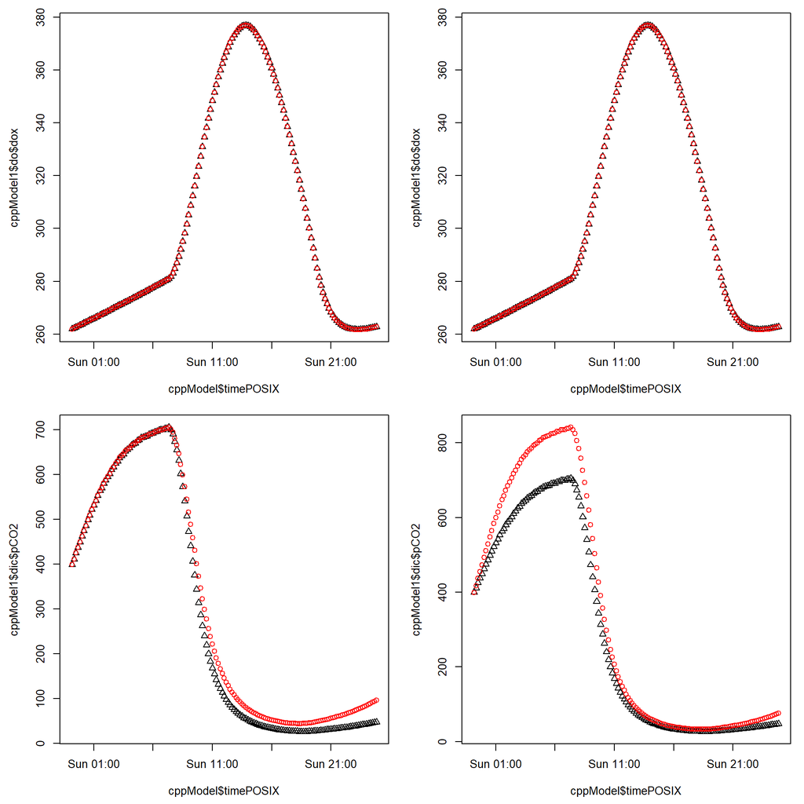

```r
par(
   mfcol = c(2, 2),
   mar = c(4.5, 4.5, 1, 1)
)

# Test RatioDoCFix
cppModel1 <- cppModel$run();

old <- cppModel$setMetabDoDicParam("RatioDicCFix", -0.8);

cppModel2 <- cppModel$run();

new <- cppModel$setMetabDoDicParam("RatioDicCFix", old);

plotComparison();
plotComparisonpCO2();

# Test RatioDoCFix
cppModel1 <- cppModel$run();

old <- cppModel$setMetabDoDicParam("RatioDicCResp", 1.4);

cppModel2 <- cppModel$run();

new <- cppModel$setMetabDoDicParam("RatioDicCResp", old);

plotComparison();
plotComparisonpCO2();
```

## DO and DIC Lagrange

Set values for test

```r
gpp <- 610
gppdo <- 1
er <- 275
erdo <- -1
k600 <- 19.5
upstreamDO <- signalIn$getVariable("do");
upstreamTime <- signalIn$time
downstreamTime <- signalOut$time
upstreamTemp <- signalIn$getVariable("temp")
downstreamTemp <- signalOut$getVariable("temp")
upstreamPAR <- signalIn$getVariable("par")
downstreamPAR <- signalOut$getVariable("par")
parTotal <- -1
airPressure <- 638
stdAirPressure <- 760

gppdic <- -1
erdic <- 1
upstreamDIC <- signalOut$getVariable("dic")
upstreamDIC[15:17] <- 2846.699
pCO2Air <- 400;
upstreamAlkalinity <- 2857;
downstreamAlkalinity <- 2857;
```

### DO Lagrange

Compare the GPP set to 610 (black triangles) and the GPP set to 300 (red circles), based on changing the model with the setter method.

Compare the ER set to 275 (black triangles) and the ER set to 500 (red circles), based on changing the model with the setter method.

Compare the k600 set to 19.5 (black triangles) and the k600 set to 10 (red circles), based on changing the model with the setter method.

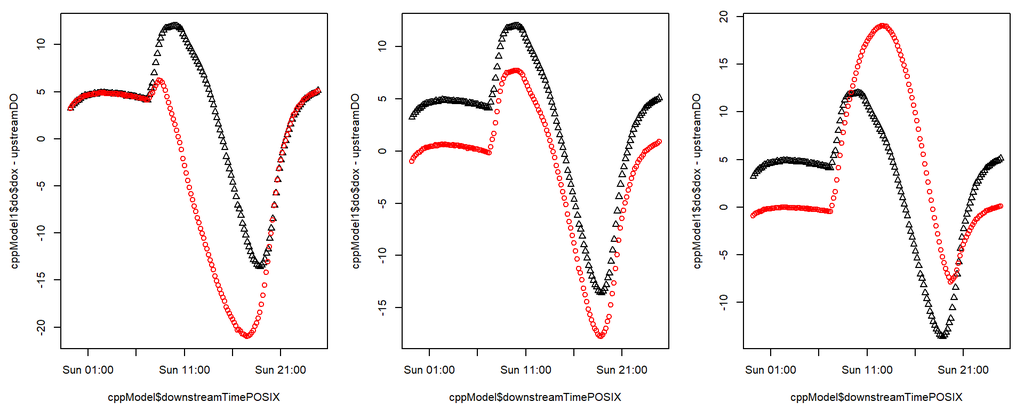

Compare the RatioDoCFix set to 1 (black triangles) and the RatioDoCFix set to 0.8 (red circles), based on changing the model with the setter method.

Compare the RatioDoCResp set to -1 (black triangles) and the RatioDoCResp set to -1.4 (red circles), based on changing the model with the setter method.

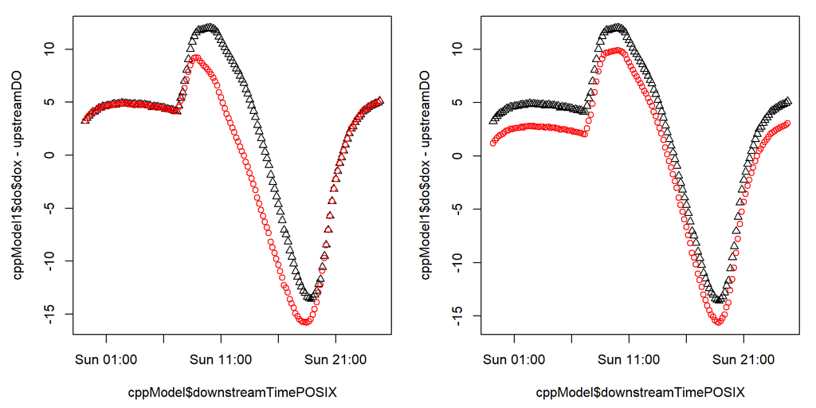

```r
par(
   mfrow = c(1, 2),
   mar = c(4.5, 4.5, 1, 1)
)

# Test ratioDoCFix
cppModel1 <- cppModel$run();

old <- cppModel$setMetabLagrangeDoParam("RatioDoCFix", 0.8);

cppModel2 <- cppModel$run();

new <- cppModel$setMetabLagrangeDoParam("RatioDoCFix", old);

plotComparison();

# Test ratioDoCResp
cppModel1 <- cppModel$run();

old <- cppModel$setMetabLagrangeDoParam("RatioDoCResp", -1.4);

cppModel2 <- cppModel$run();

new <- cppModel$setMetabLagrangeDoParam("RatioDoCResp", old);

plotComparison();
```

### DIC Lagrange

Compare the GPP set to 610 (black triangles) and the GPP set to 300 (red circles), based on changing the model with the setter method.

Compare the ER set to 275 (black triangles) and the ER set to 500 (red circles), based on changing the model with the setter method.

Compare the k600 set to 19.5 (black triangles) and the k600 set to 10 (red circles), based on changing the model with the setter method.

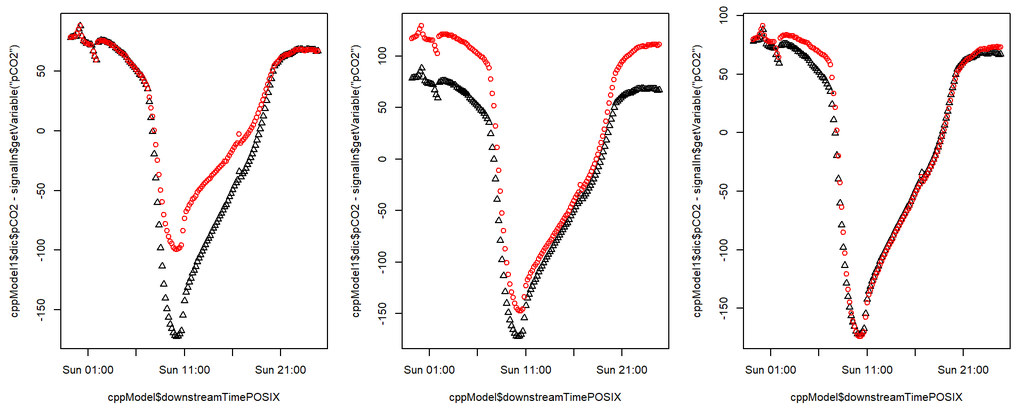

Compare the RatioDoCFix set to 1 (black triangles) and the RatioDoCFix set to 0.8 (red circles), based on changing the model with the setter method.

Compare the RatioDoCResp set to -1 (black triangles) and the RatioDoCResp set to -1.4 (red circles), based on changing the model with the setter method.

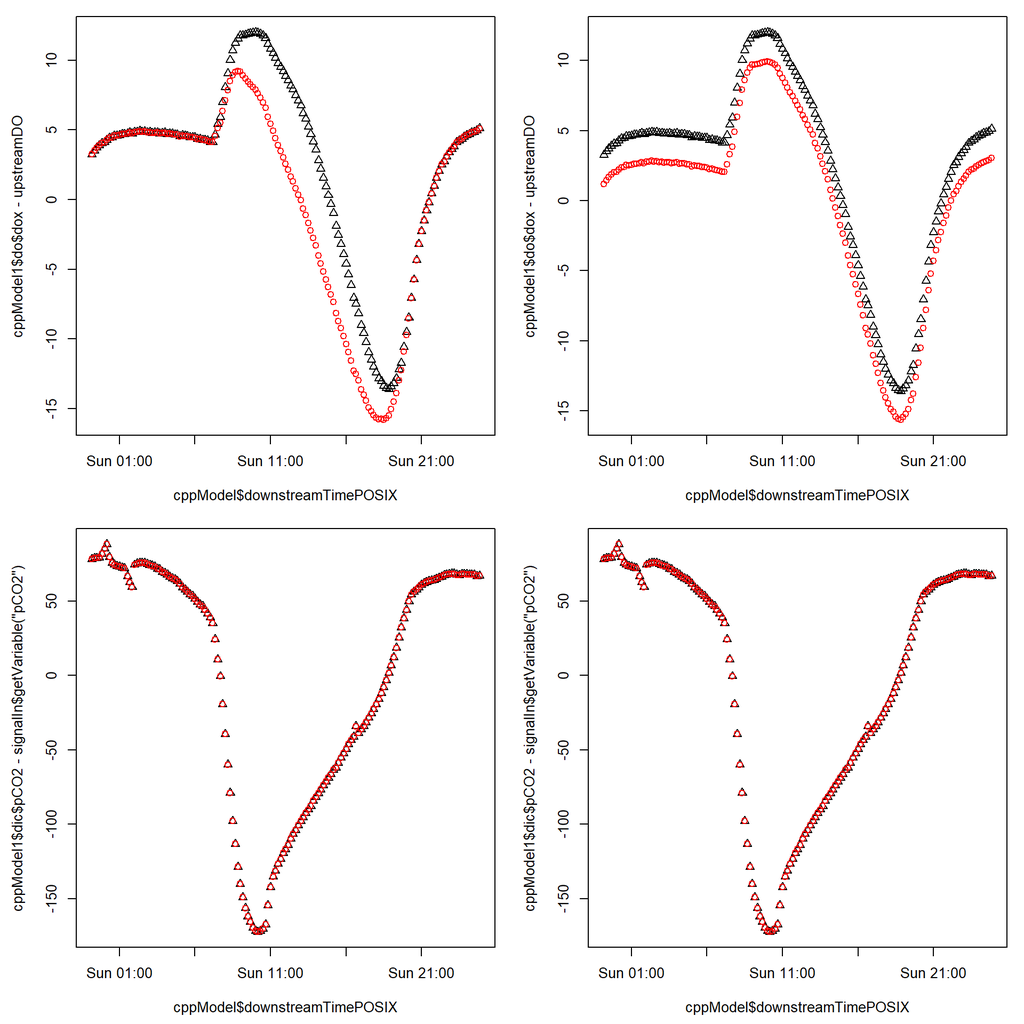

```r
par(
   mfcol = c(2, 2),
   mar = c(4.5, 4.5, 1, 1)
)

# Test RatioDoCFix
cppModel1 <- cppModel$run();

old <- cppModel$setMetabLagrangeDoDicParam("RatioDoCFix", 0.8);

cppModel2 <- cppModel$run();

new <- cppModel$setMetabLagrangeDoDicParam("RatioDoCFix", old);

plotComparison();
plotComparisonpCO2();

# Test RatioDoCFix
cppModel1 <- cppModel$run();

old <- cppModel$setMetabLagrangeDoDicParam("RatioDoCResp", -1.4);

cppModel2 <- cppModel$run();

new <- cppModel$setMetabLagrangeDoDicParam("RatioDoCResp", old);

plotComparison();
plotComparisonpCO2();
```

Compare the RatioDicCFix set to -1 (black triangles) and the RatioDicCFix set to -0.8 (red circles), based on changing the model with the setter method.

Compare the RatioDicCResp set to 1 (black triangles) and the RatioDicCResp set to 1.4 (red circles), based on changing the model with the setter method.

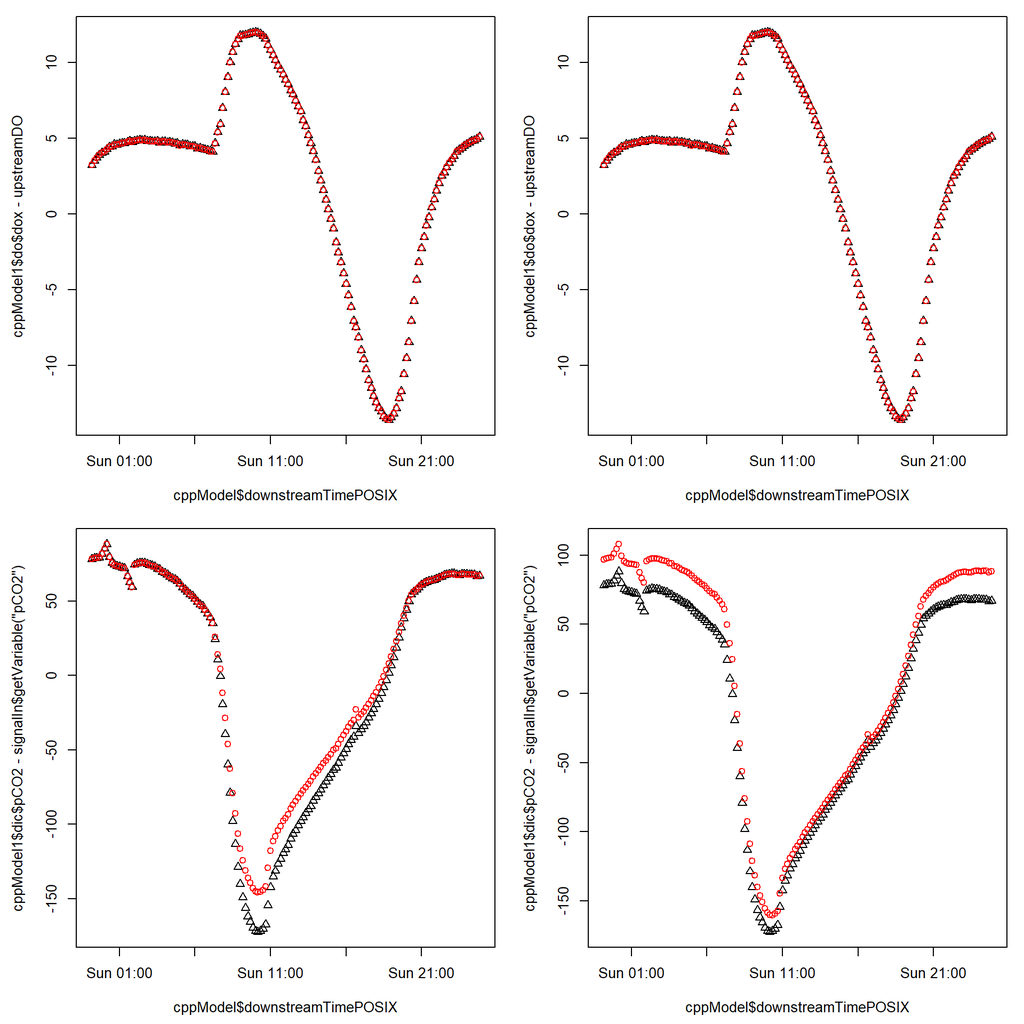

```r
par(
   mfcol = c(2, 2),
   mar = c(4.5, 4.5, 1, 1)
)

# Test RatioDoCFix
cppModel1 <- cppModel$run();

old <- cppModel$setMetabLagrangeDoDicParam("RatioDicCFix", -0.8);

cppModel2 <- cppModel$run();

new <- cppModel$setMetabLagrangeDoDicParam("RatioDicCFix", old);

plotComparison();
plotComparisonpCO2();

# Test RatioDoCFix
cppModel1 <- cppModel$run();

old <- cppModel$setMetabLagrangeDoDicParam("RatioDicCResp", 1.4);

cppModel2 <- cppModel$run();

new <- cppModel$setMetabLagrangeDoDicParam("RatioDicCResp", old);

plotComparison();
plotComparisonpCO2();
```